# Proyecto Analisis de Datos - Analisis

### Modelo de *Forecast* de demanda para el uso de máquinas de entretenimiento en un casino de Chile

```python
import pandas as pd
import numpy as np
import matplotlib.pyplot as plt
import researchpy as rp
import scipy.stats as stats
from scipy.stats import f_oneway
import seaborn
from datetime import datetime, timedelta
import matplotlib.dates as mdates
from Funciones.Funciones_feriados_semana import Feriado, Diaantesdeferiado, semana_del_mes
```

```python
df_arima=pd.read_csv('C:/Users/adolf/Desktop/Python/UDD/analisis/proyecto/Data/processed/datos_modelo.csv')
df_arima
```

|  | datetime | Sesiones |
| --- | --- | --- |
| 0 | 2022-01-01 00:00:00 | 620 |
| 1 | 2022-01-01 01:00:00 | 566 |
| 2 | 2022-01-01 02:00:00 | 472 |
| 3 | 2022-01-01 03:00:00 | 369 |
| 4 | 2022-01-01 04:00:00 | 247 |
| ... | ... | ... |
| 6067 | 2022-09-10 19:00:00 | 307 |
| 6068 | 2022-09-10 20:00:00 | 399 |
| 6069 | 2022-09-10 21:00:00 | 460 |
| 6070 | 2022-09-10 22:00:00 | 561 |
| 6071 | 2022-09-10 23:00:00 | 638 |

6072 rows × 2 columns

### Media Movil

**Evaluaremos la Media movil de la serie de tiempo y la desviacion estandar para una ventana que considere una ventana movil de los ultimos 6 periodos y lo compararemos con la oiriginal. Para que pueda ser visible en el grafico eligiremos nuevamente la segunda semana de enero**

```python
df_arima_enero=df_arima[240:408]
df_arima_enero
```

|  | datetime | Sesiones |
| --- | --- | --- |
| 240 | 2022-01-11 00:00:00 | 181 |
| 241 | 2022-01-11 01:00:00 | 141 |
| 242 | 2022-01-11 02:00:00 | 122 |
| 243 | 2022-01-11 03:00:00 | 70 |
| 244 | 2022-01-11 04:00:00 | 9 |
| ... | ... | ... |
| 403 | 2022-01-17 19:00:00 | 106 |
| 404 | 2022-01-17 20:00:00 | 94 |
| 405 | 2022-01-17 21:00:00 | 105 |
| 406 | 2022-01-17 22:00:00 | 130 |
| 407 | 2022-01-17 23:00:00 | 144 |

168 rows × 2 columns

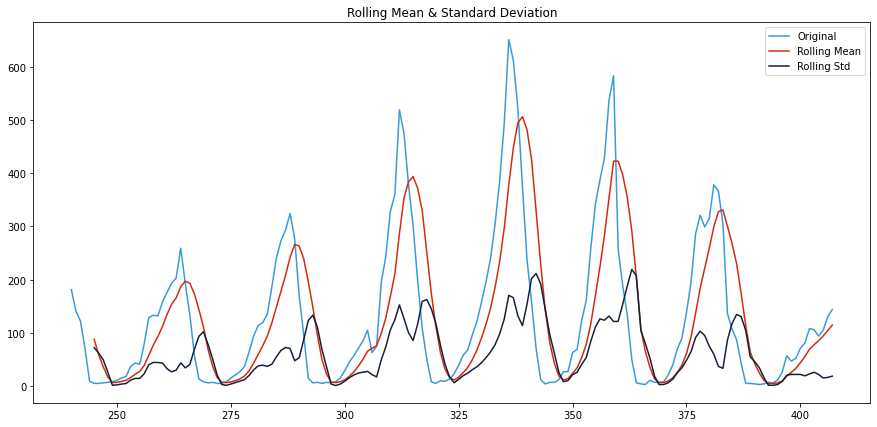

```python
df_arima_enero["rolling_avg"] = df_arima_enero["Sesiones"].rolling(window=6).mean()
df_arima_enero["rolling_std"] = df_arima_enero["Sesiones"].rolling(window=6).std()


plt.figure(figsize=(15,7))
plt.plot(df_arima_enero["Sesiones"], color='#379BDB', label='Original')
plt.plot(df_arima_enero["rolling_avg"], color='#D22A0D', label='Rolling Mean')
plt.plot(df_arima_enero["rolling_std"], color='#142039', label='Rolling Std')
plt.legend(loc='best')
plt.title('Rolling Mean & Standard Deviation')
plt.show(block=False)
```

**Llevamos el Dataframe al formato que será aceptado por la libreria de ARIMA, esto es un array con solo 1 valor y en el indice debe estar el datetime con timestamp**

```python
df_arima.index=df_arima['datetime']
df_arima=df_arima.drop(['datetime'],axis=1)
array_arima=df_arima['Sesiones']
array_arima
```

```
datetime
2022-01-01 00:00:00    620
2022-01-01 01:00:00    566
2022-01-01 02:00:00    472
2022-01-01 03:00:00    369
2022-01-01 04:00:00    247
                      ...
2022-09-10 19:00:00    307
2022-09-10 20:00:00    399
2022-09-10 21:00:00    460
2022-09-10 22:00:00    561
2022-09-10 23:00:00    638
Name: Sesiones, Length: 6072, dtype: int64
```

### Train Test Serie de Tiempo

**Realizamos Split Train y Test**

```python
Truth=array_arima[-24:]
Truth
```

```
datetime
2022-09-10 00:00:00    628
2022-09-10 01:00:00    513
2022-09-10 02:00:00    400
2022-09-10 03:00:00    117
2022-09-10 04:00:00    145
2022-09-10 05:00:00     83
2022-09-10 06:00:00     12
2022-09-10 07:00:00      7
2022-09-10 08:00:00      4
2022-09-10 09:00:00      0
2022-09-10 10:00:00      1
2022-09-10 11:00:00      9
2022-09-10 12:00:00     25
2022-09-10 13:00:00     23
2022-09-10 14:00:00     61
2022-09-10 15:00:00     93
2022-09-10 16:00:00    181
2022-09-10 17:00:00    233
2022-09-10 18:00:00    252
2022-09-10 19:00:00    307
2022-09-10 20:00:00    399
2022-09-10 21:00:00    460
2022-09-10 22:00:00    561
2022-09-10 23:00:00    638
Name: Sesiones, dtype: int64
```

```python
Train=array_arima[:-24]
Train
```

```
datetime
2022-01-01 00:00:00    620
2022-01-01 01:00:00    566
2022-01-01 02:00:00    472
2022-01-01 03:00:00    369
2022-01-01 04:00:00    247
                      ...
2022-09-09 19:00:00     84
2022-09-09 20:00:00    269
2022-09-09 21:00:00    356
2022-09-09 22:00:00    486
2022-09-09 23:00:00    635
Name: Sesiones, Length: 6048, dtype: int64
```

### Forecast - Modelo ARIMA

**Importamos librerias de ARIMA**

```python
from statsmodels.tsa.arima.model import ARIMA
from statsmodels.graphics.tsaplots import plot_pacf
import matplotlib.pyplot as plt
import warnings
```

**Entrenamos el Modelo**

**Solo al probar algunas combinaciones y saber previamente que el ciclo natural de cada dia es de cada 24 horas, partiremos con parametro de media movil de 24 y solo los ultimos 2 componentes autoregresivos, o autoregresivo de segundo orden**

```python
from datetime import datetime
start_time = datetime.now()
model1 = ARIMA(Train, order=(2, 0, 24))
model_fit1 = model1.fit()
end_time = datetime.now()
print('Duration: {}'.format(end_time - start_time))
```

```
Duration: 0:01:34.509104
```

```python
print(model_fit1.summary())
```

```
                               SARIMAX Results
==============================================================================
Dep. Variable:               Sesiones   No. Observations:                 6048
Model:                ARIMA(2, 0, 24)   Log Likelihood              -33693.419
Date:                Mon, 17 Oct 2022   AIC                          67442.839
Time:                        18:47:17   BIC                          67630.648
Sample:                    01-01-2022   HQIC                         67508.033
                         - 09-09-2022
Covariance Type:                  opg
==============================================================================
                 coef    std err          z      P>|z|      [0.025      0.975]
------------------------------------------------------------------------------
const        127.4602      7.025     18.143      0.000     113.691     141.229
ar.L1          1.8577      0.013    147.094      0.000       1.833       1.882
ar.L2         -0.9290      0.011    -81.817      0.000      -0.951      -0.907
ma.L1         -1.0904      0.016    -69.697      0.000      -1.121      -1.060
ma.L2          0.1462      0.011     13.796      0.000       0.125       0.167
ma.L3          0.0654      0.014      4.827      0.000       0.039       0.092
ma.L4         -0.0367      0.017     -2.206      0.027      -0.069      -0.004
ma.L5          0.0592      0.019      3.112      0.002       0.022       0.097
ma.L6          0.0307      0.020      1.506      0.132      -0.009       0.071
ma.L7         -0.0141      0.026     -0.532      0.594      -0.066       0.038
ma.L8          0.0449      0.034      1.329      0.184      -0.021       0.111
ma.L9          0.0114      0.038      0.300      0.764      -0.063       0.086
ma.L10         0.0178      0.045      0.395      0.693      -0.070       0.106
ma.L11        -0.0141      0.046     -0.305      0.761      -0.105       0.077
ma.L12         0.0059      0.045      0.132      0.895      -0.082       0.094
ma.L13         0.0029      0.046      0.063      0.950      -0.088       0.094
ma.L14         0.0090      0.046      0.196      0.845      -0.081       0.099
ma.L15        -0.0328      0.039     -0.847      0.397      -0.109       0.043
ma.L16        -0.0061      0.032     -0.192      0.848      -0.068       0.056
ma.L17         0.0390      0.028      1.403      0.161      -0.016       0.094
ma.L18         0.0049      0.024      0.206      0.837      -0.042       0.052
ma.L19        -0.0063      0.019     -0.324      0.746      -0.044       0.032
ma.L20         0.0311      0.017      1.800      0.072      -0.003       0.065
ma.L21         0.0353      0.015      2.368      0.018       0.006       0.065
ma.L22         0.0722      0.012      5.810      0.000       0.048       0.097
ma.L23         0.0723      0.011      6.437      0.000       0.050       0.094
ma.L24        -0.1194      0.009    -13.179      0.000      -0.137      -0.102
sigma2      4018.6517     28.164    142.687      0.000    3963.451    4073.852
===================================================================================
Ljung-Box (L1) (Q):                   0.12   Jarque-Bera (JB):            146154.61
Prob(Q):                              0.73   Prob(JB):                         0.00
Heteroskedasticity (H):               1.45   Skew:                             1.10
Prob(H) (two-sided):                  0.00   Kurtosis:                        26.98
===================================================================================

Warnings:
[1] Covariance matrix calculated using the outer product of gradients (complex-step).
```

**Predecimos para los siguentes 24 registros**

```python
Predition1 = model_fit1.forecast(steps=24)
Predition1
```

```
2022-09-10 00:00:00    588.742802
2022-09-10 01:00:00    520.895696
2022-09-10 02:00:00    431.325237
2022-09-10 03:00:00    331.719626
2022-09-10 04:00:00    232.027166
2022-09-10 05:00:00    136.683918
2022-09-10 06:00:00     52.782361
2022-09-10 07:00:00    -11.729070
2022-09-10 08:00:00    -64.764795
2022-09-10 09:00:00   -103.266797
2022-09-10 10:00:00   -115.788185
2022-09-10 11:00:00   -112.307832
2022-09-10 12:00:00    -97.415258
2022-09-10 13:00:00    -65.674588
2022-09-10 14:00:00    -22.997495
2022-09-10 15:00:00     28.527010
2022-09-10 16:00:00     93.839064
2022-09-10 17:00:00    143.985779
2022-09-10 18:00:00    192.937040
2022-09-10 19:00:00    261.868758
2022-09-10 20:00:00    313.944910
2022-09-10 21:00:00    355.062706
2022-09-10 22:00:00    375.638196
2022-09-10 23:00:00    367.284942
Freq: H, Name: predicted_mean, dtype: float64
```

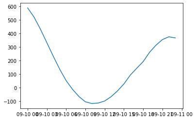

```python
plt.plot(Predition1)
```

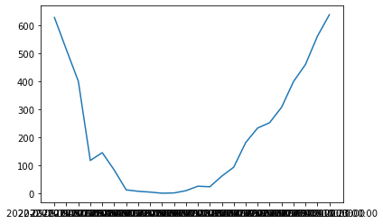

```python
plt.plot(Truth)
```

## AUTO ARIMA

**Utilizaremos auto arima para evaluar que coeficientes p,q y d son los optimos dada la limitación de procesamiento para hacer un grid search manual**

```python
import pmdarima as pm
```

```python
ARIMA_model = pm.auto_arima(Train,
                      start_p=1,
                      start_q=1,
                      test='adf', # use adftest to find optimal 'd'
                      max_p=48, max_q=48, # maximum p and q
                      m=1, # frequency of series (if m==1, seasonal is set to FALSE automatically)
                      d=None,# let model determine 'd'
                      seasonal=False, # No Seasonality for standard ARIMA
                      trace=False, #logs
                      error_action='warn', #shows errors ('ignore' silences these)
                      suppress_warnings=True,
                      stepwise=True)
```

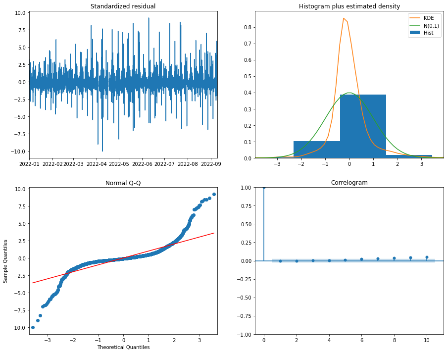

```python
ARIMA_model.plot_diagnostics(figsize=(15,12))
plt.show()
```

```python
ARIMA_model.summary()
```

SARIMAX Results

| Dep. Variable: | y | No. Observations: | 6048 |
| --- | --- | --- | --- |
| Model: | SARIMAX(12, 0, 0) | Log Likelihood | -34135.706 |
| Date: | Mon, 17 Oct 2022 | AIC | 68299.412 |
| Time: | 18:50:07 | BIC | 68393.317 |
| Sample: | 01-01-2022 | HQIC | 68332.009 |
|  | - 09-09-2022 |  |  |
| Covariance Type: | opg |  |  |

|  | coef | std err | z | P>\|z\| | [0.025 | 0.975] |
| --- | --- | --- | --- | --- | --- | --- |
| intercept | 41.8355 | 2.559 | 16.351 | 0.000 | 36.821 | 46.850 |
| ar.L1 | 0.9080 | 0.007 | 135.767 | 0.000 | 0.895 | 0.921 |
| ar.L2 | 0.0361 | 0.009 | 4.118 | 0.000 | 0.019 | 0.053 |
| ar.L3 | -0.0210 | 0.012 | -1.718 | 0.086 | -0.045 | 0.003 |
| ar.L4 | -0.1080 | 0.016 | -6.947 | 0.000 | -0.138 | -0.078 |
| ar.L5 | -0.0241 | 0.017 | -1.408 | 0.159 | -0.058 | 0.009 |
| ar.L6 | -0.0148 | 0.019 | -0.799 | 0.425 | -0.051 | 0.022 |
| ar.L7 | -0.0408 | 0.027 | -1.527 | 0.127 | -0.093 | 0.012 |
| ar.L8 | 0.0059 | 0.032 | 0.183 | 0.855 | -0.057 | 0.069 |
| ar.L9 | -0.0029 | 0.037 | -0.078 | 0.938 | -0.075 | 0.070 |
| ar.L10 | 0.0012 | 0.046 | 0.027 | 0.978 | -0.088 | 0.091 |
| ar.L11 | -0.0400 | 0.048 | -0.833 | 0.405 | -0.134 | 0.054 |
| ar.L12 | -0.0275 | 0.035 | -0.788 | 0.430 | -0.096 | 0.041 |
| sigma2 | 4675.7343 | 33.594 | 139.182 | 0.000 | 4609.891 | 4741.578 |

| Ljung-Box (L1) (Q): | 0.01 | Jarque-Bera (JB): | 106412.85 |
| --- | --- | --- | --- |
| Prob(Q): | 0.91 | Prob(JB): | 0.00 |
| Heteroskedasticity (H): | 1.41 | Skew: | 0.89 |
| Prob(H) (two-sided): | 0.00 | Kurtosis: | 23.47 |

Warnings:  
[1] Covariance matrix calculated using the outer product of gradients (complex-step).

**El modelo optimo arrojado por autoarima es de orden (12, 0, 0) lo que significa que solo sería un autoregresivo de orden 12, es decir que el valor anterior está basado en los ultimos 12 registros. Esto es interesante porque una ventana temporal de 12 horas (12 registros en este *dataframe*) es representativa para los datos analizados de esta manera.**

**Por otro lado, el análisis fue realizado con el parámetro _max*q=48*, por lo que solo incorpora como variables los últimos 48 registros para entrenar y predecir. Este parámetro fue fijado en función del poder de cómputo que toma este análisis, el que crece exponencialmente si es que aumentáramos a _max*q* a un valor que incorpore registros que pudiesen reflejar otros patrones de estacionalidad que ahora no han sido considerados.**

```python
model2 = ARIMA(Train, order=(12, 0, 0))  #Parametros de ARIMA
model_fit2 = model2.fit()
```

```python
Predition2 = model_fit2.forecast(steps=24)
Predition2
```

```
2022-09-10 00:00:00    588.331710
2022-09-10 01:00:00    534.728440
2022-09-10 02:00:00    464.276674
2022-09-10 03:00:00    371.490420
2022-09-10 04:00:00    279.106256
2022-09-10 05:00:00    189.078292
2022-09-10 06:00:00    112.687644
2022-09-10 07:00:00     51.572990
2022-09-10 08:00:00      1.539052
2022-09-10 09:00:00    -35.898532
2022-09-10 10:00:00    -64.706003
2022-09-10 11:00:00    -80.260148
2022-09-10 12:00:00    -79.898141
2022-09-10 13:00:00    -66.344804
2022-09-10 14:00:00    -41.107684
2022-09-10 15:00:00     -6.745665
2022-09-10 16:00:00     33.300522
2022-09-10 17:00:00     75.686802
2022-09-10 18:00:00    116.898371
2022-09-10 19:00:00    154.103204
2022-09-10 20:00:00    185.291533
2022-09-10 21:00:00    209.252443
2022-09-10 22:00:00    225.414572
2022-09-10 23:00:00    233.590065
Freq: H, Name: predicted_mean, dtype: float64
```

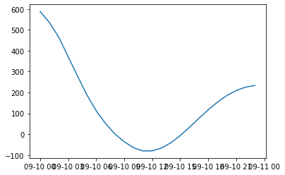

```python
plt.plot(Predition2)
```

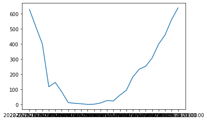

```python
plt.plot(Truth)
```

**El modelo capta el patrón de manera correcta, solo que existe una restricción logica que implica que el numero de pronostico no puede ser menor a cero (dado que es el uso de máquinas). Por ende, agregaremos la siguente regla de negocio: que si el modelo es negativo entonces será reemplazado por el valor cero, sin embargo probaremos otros modelos que puedan capturar este efecto**

### Forecast SARIMA

```python
import statsmodels.api as sm
```

```python
model3 = sm.tsa.statespace.SARIMAX(Train, order=(12,0,0), seasonal_order=(1,0,0,24))
#                                   enforce_stationarity=False,
#                                   enforce_invertibility=False)
model_fit3 = model3.fit()
```

```python
Predition3 = model_fit3.forecast(steps=24)
Predition3.index = pd.to_datetime(Predition3.index)
Predition3
```

```
2022-09-10 00:00:00    688.299986
2022-09-10 01:00:00    623.087319
2022-09-10 02:00:00    546.733440
2022-09-10 03:00:00    432.415735
2022-09-10 04:00:00    341.088578
2022-09-10 05:00:00    259.074231
2022-09-10 06:00:00    195.242103
2022-09-10 07:00:00    129.966681
2022-09-10 08:00:00     96.262653
2022-09-10 09:00:00     70.965211
2022-09-10 10:00:00     54.891287
2022-09-10 11:00:00     55.795136
2022-09-10 12:00:00     56.030574
2022-09-10 13:00:00     64.198137
2022-09-10 14:00:00     74.055260
2022-09-10 15:00:00     78.938921
2022-09-10 16:00:00     76.618825
2022-09-10 17:00:00    104.512392
2022-09-10 18:00:00    105.318824
2022-09-10 19:00:00     82.657669
2022-09-10 20:00:00    123.947830
2022-09-10 21:00:00    139.435285
2022-09-10 22:00:00    165.425355
2022-09-10 23:00:00    196.802963
Freq: H, Name: predicted_mean, dtype: float64
```

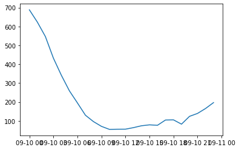

```python
plt.plot(Predition3)
```

```python
real=array_arima[-72:]
real.index = pd.to_datetime(real.index)
real
```

```
datetime
2022-09-08 00:00:00    300
2022-09-08 01:00:00    110
2022-09-08 02:00:00    153
2022-09-08 03:00:00     60
2022-09-08 04:00:00      8
                      ...
2022-09-10 19:00:00    307
2022-09-10 20:00:00    399
2022-09-10 21:00:00    460
2022-09-10 22:00:00    561
2022-09-10 23:00:00    638
Name: Sesiones, Length: 72, dtype: int64
```

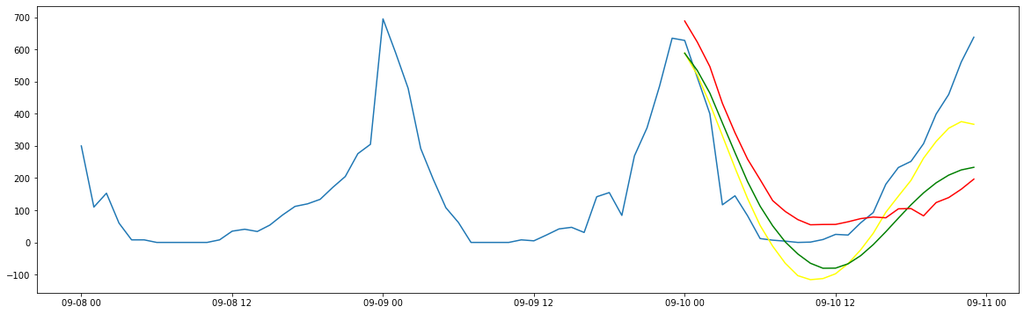

```python
plt.figure(figsize=(20, 6))
plt.plot(real)
plt.plot(Predition1, color='yellow')
plt.plot(Predition2, color='green')
plt.plot(Predition3, color='red')
```

```python
Predition_final= [0 if i < 0 else i for i in Predition1.values]
Predition_final
```

```
[588.7428016861064,
 520.8956964421797,
 431.32523717632404,
 331.719626116442,
 232.0271662746137,
 136.68391790281436,
 52.782361021790635,
 0,
 0,
 0,
 0,
 0,
 0,
 0,
 0,
 28.527009836821506,
 93.83906401358165,
 143.985779133908,
 192.93703990229798,
 261.8687578825139,
 313.9449100432547,
 355.06270639341403,
 375.63819612766747,
 367.2849422611639]
```

```python
Predition_final=pd.Series(Predition_final,index=Predition1.index)
Predition_final
```

```
2022-09-10 00:00:00    588.742802
2022-09-10 01:00:00    520.895696
2022-09-10 02:00:00    431.325237
2022-09-10 03:00:00    331.719626
2022-09-10 04:00:00    232.027166
2022-09-10 05:00:00    136.683918
2022-09-10 06:00:00     52.782361
2022-09-10 07:00:00      0.000000
2022-09-10 08:00:00      0.000000
2022-09-10 09:00:00      0.000000
2022-09-10 10:00:00      0.000000
2022-09-10 11:00:00      0.000000
2022-09-10 12:00:00      0.000000
2022-09-10 13:00:00      0.000000
2022-09-10 14:00:00      0.000000
2022-09-10 15:00:00     28.527010
2022-09-10 16:00:00     93.839064
2022-09-10 17:00:00    143.985779
2022-09-10 18:00:00    192.937040
2022-09-10 19:00:00    261.868758
2022-09-10 20:00:00    313.944910
2022-09-10 21:00:00    355.062706
2022-09-10 22:00:00    375.638196
2022-09-10 23:00:00    367.284942
Freq: H, dtype: float64
```

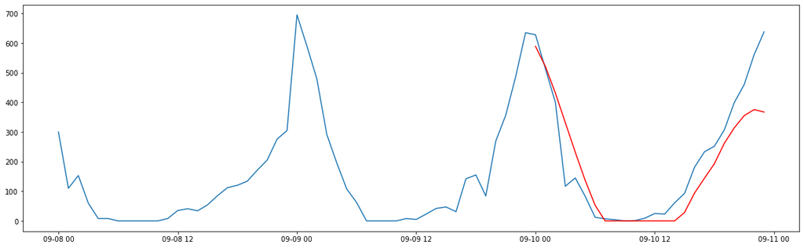

```python
plt.figure(figsize=(20, 6))
plt.plot(real)
plt.plot(Predition_final, color='red')
```

### Indicadores de Desempeño

```python
from sklearn.metrics import mean_absolute_error
mae = mean_absolute_error(Truth, Predition_final)
mae
```

```
66.48344990222645
```

```python
from sklearn.metrics import mean_squared_error
mse = mean_squared_error(Truth, Predition_final)
mse
```

```
9038.524308131104
```

```python
from sklearn.metrics import mean_squared_error
from math import sqrt
mse = mean_squared_error(Truth, Predition_final)
rmse = sqrt(mse)
rmse
```

```
95.07115392237071
```